# Exploratory Data Analysis: `mtcars`

Eugene Joh

Wednesday, December 05, 2018

# Overview

This parameterized markdown file is a standarized exploratory analysis report, examining the data type, structure, missing values, unique values, summary statistics for continuous and categorical variables contained within a `data.frame` object.

This does not support `date-time` varaibles such as `POSIXct` or `Date`, but will eventually move to support all data types typically found in `data.frame` in the R environment.

# Data Structure

Dataset Dimensions

| Name | Number of Columns | Number of Rows | Number of Elements | Memory Allocation |
| --- | --- | --- | --- | --- |
| mtcars | 11 | 32 | 352 | 7 Kb |

Dataset Variable Class and Missing Values

| Variable | Class | missing |
| --- | --- | --- |
| mpg | numeric | 0 |
| cyl | numeric | 0 |
| disp | numeric | 0 |
| hp | numeric | 0 |
| drat | numeric | 0 |
| wt | numeric | 0 |
| qsec | numeric | 0 |
| vs | numeric | 0 |
| am | numeric | 0 |
| gear | numeric | 0 |
| carb | numeric | 0 |

# Missing Values, Data Type, Unique Values

## Table

The table below displays the data type, counts/proportion of missing values `NA`, and whether the data is labelled or not.

|  | Variable | Missing (n) | Missing (%) | Exist (%) | Data Type | Labelled |
| --- | --- | --- | --- | --- | --- | --- |
| 1 | mpg | 0 | 0 | 100 | numeric | False |
| 2 | cyl | 0 | 0 | 100 | numeric | False |
| 3 | disp | 0 | 0 | 100 | numeric | False |
| 4 | hp | 0 | 0 | 100 | numeric | False |
| 5 | drat | 0 | 0 | 100 | numeric | False |
| 6 | wt | 0 | 0 | 100 | numeric | False |
| 7 | qsec | 0 | 0 | 100 | numeric | False |
| 8 | vs | 0 | 0 | 100 | numeric | False |
| 9 | am | 0 | 0 | 100 | numeric | False |
| 10 | gear | 0 | 0 | 100 | numeric | False |

[output cut: 1 more lines]

## Plot

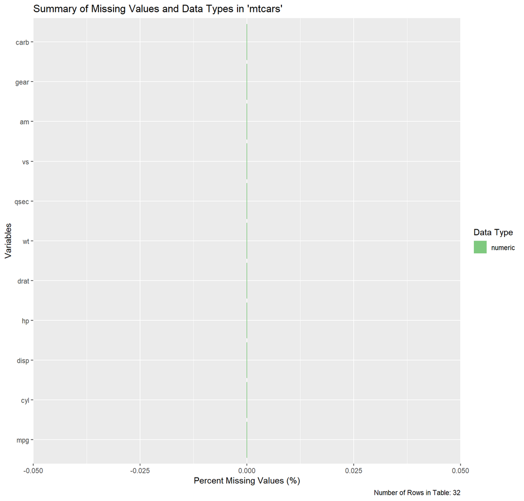

## Unique Values

|  | Variable | Counts | Percentage of Total Rows |
| --- | --- | --- | --- |
| 1 | mpg | 25 | 78.12 |
| 2 | cyl | 3 | 9.38 |
| 3 | disp | 27 | 84.38 |
| 4 | hp | 22 | 68.75 |
| 5 | drat | 22 | 68.75 |
| 6 | wt | 29 | 90.62 |
| 7 | qsec | 30 | 93.75 |
| 8 | vs | 2 | 6.25 |
| 9 | am | 2 | 6.25 |
| 10 | gear | 3 | 9.38 |

[output cut: 1 more lines]

# Variable Content

This section contains an analysis of the variable content composition by describing the type of data content that exist based on **numeric** values, **character** values, **punctuation** or **symbols**, and **blank** space. This is especially useful when data types are not identified or misclassified.

## Only Numbers

**only_numbs** reports the number of rows that contain only digits `"^[0-9]{1,}$"` and **numpercent** is the respective percentage. **digits_min** and **digits_max** display the length of the digits found in the variable, **digits_eq** is a logical statment of whether the mix and max are equal.

|  | variable | only_numbs | n_row | numpercent | digits_min | digits_max | digits_eq |
| --- | --- | --- | --- | --- | --- | --- | --- |
| 1 | mpg | 32 | 32 | 100 | 2 | 2 | True |
| 2 | cyl | 32 | 32 | 100 | 1 | 1 | True |
| 3 | disp | 32 | 32 | 100 | 2 | 3 | False |
| 4 | hp | 32 | 32 | 100 | 2 | 3 | False |
| 5 | drat | 32 | 32 | 100 | 1 | 1 | True |
| 6 | wt | 32 | 32 | 100 |  |  | False |
| 7 | qsec | 32 | 32 | 100 | 2 | 2 | True |
| 8 | vs | 32 | 32 | 100 | 1 | 1 | True |
| 9 | am | 32 | 32 | 100 | 1 | 1 | True |
| 10 | gear | 32 | 32 | 100 | 1 | 1 | True |

[output cut: 1 more lines]

## Only Character

**only_char** reports the number of rows that contain only characters `"^[A-z]{1,}"` and **charpercent** is the respective percentage.

|  | variable | only_char | n_row | charpercent |
| --- | --- | --- | --- | --- |
| 1 | mpg | 0 | 32 | 0 |
| 2 | cyl | 0 | 32 | 0 |
| 3 | disp | 0 | 32 | 0 |
| 4 | hp | 0 | 32 | 0 |
| 5 | drat | 0 | 32 | 0 |
| 6 | wt | 0 | 32 | 0 |
| 7 | qsec | 0 | 32 | 0 |
| 8 | vs | 0 | 32 | 0 |
| 9 | am | 0 | 32 | 0 |
| 10 | gear | 0 | 32 | 0 |

[output cut: 1 more lines]

## Only Punctuation

**only_punc** reports the number of rows that contain only punctuation or symbols `"^\\W+$"` and **puncpercentage** is the respective percentage.

|  | variable | only_punc | n_row | puncpercent |
| --- | --- | --- | --- | --- |
| 1 | mpg | 0 | 32 | 0 |
| 2 | cyl | 0 | 32 | 0 |
| 3 | disp | 0 | 32 | 0 |
| 4 | hp | 0 | 32 | 0 |
| 5 | drat | 0 | 32 | 0 |
| 6 | wt | 0 | 32 | 0 |
| 7 | qsec | 0 | 32 | 0 |
| 8 | vs | 0 | 32 | 0 |
| 9 | am | 0 | 32 | 0 |
| 10 | gear | 0 | 32 | 0 |

[output cut: 1 more lines]

## Only Blanks

**only_blanks** reports the number of rows that contain a blank ("") `"^\\s{0}$"` and **blankspercent** is the respective percentage. **only_wspace** reports the number of rows that contain any white-space, including a blank `"^\\s*$"` and **wspacepercent** is the respective percentage.

|  | variable | only_blanks | blankspercent | only_wspace | wspacepercent |
| --- | --- | --- | --- | --- | --- |
| 1 | mpg | 0 | 0 | 0 | 0 |
| 2 | cyl | 0 | 0 | 0 | 0 |
| 3 | disp | 0 | 0 | 0 | 0 |
| 4 | hp | 0 | 0 | 0 | 0 |
| 5 | drat | 0 | 0 | 0 | 0 |
| 6 | wt | 0 | 0 | 0 | 0 |
| 7 | qsec | 0 | 0 | 0 | 0 |
| 8 | vs | 0 | 0 | 0 | 0 |
| 9 | am | 0 | 0 | 0 | 0 |
| 10 | gear | 0 | 0 | 0 | 0 |

[output cut: 1 more lines]

## All Types

|  | variable | only_numbs | numpercent | digits_min | digits_max | digits_eq | only_char | charpercent | only_punc | puncpercent | only_blanks | blankspercent | only_wspace | wspacepercent |
| --- | --- | --- | --- | --- | --- | --- | --- | --- | --- | --- | --- | --- | --- | --- |
| 1 | mpg | 32 | 100 | 2 | 2 | True | 0 | 0 | 0 | 0 | 0 | 0 | 0 | 0 |
| 2 | cyl | 32 | 100 | 1 | 1 | True | 0 | 0 | 0 | 0 | 0 | 0 | 0 | 0 |
| 3 | disp | 32 | 100 | 2 | 3 | False | 0 | 0 | 0 | 0 | 0 | 0 | 0 | 0 |
| 4 | hp | 32 | 100 | 2 | 3 | False | 0 | 0 | 0 | 0 | 0 | 0 | 0 | 0 |
| 5 | drat | 32 | 100 | 1 | 1 | True | 0 | 0 | 0 | 0 | 0 | 0 | 0 | 0 |
| 6 | wt | 32 | 100 |  |  | False | 0 | 0 | 0 | 0 | 0 | 0 | 0 | 0 |
| 7 | qsec | 32 | 100 | 2 | 2 | True | 0 | 0 | 0 | 0 | 0 | 0 | 0 | 0 |
| 8 | vs | 32 | 100 | 1 | 1 | True | 0 | 0 | 0 | 0 | 0 | 0 | 0 | 0 |
| 9 | am | 32 | 100 | 1 | 1 | True | 0 | 0 | 0 | 0 | 0 | 0 | 0 | 0 |
| 10 | gear | 32 | 100 | 1 | 1 | True | 0 | 0 | 0 | 0 | 0 | 0 | 0 | 0 |

[output cut: 1 more lines]

# Variable Content Plot

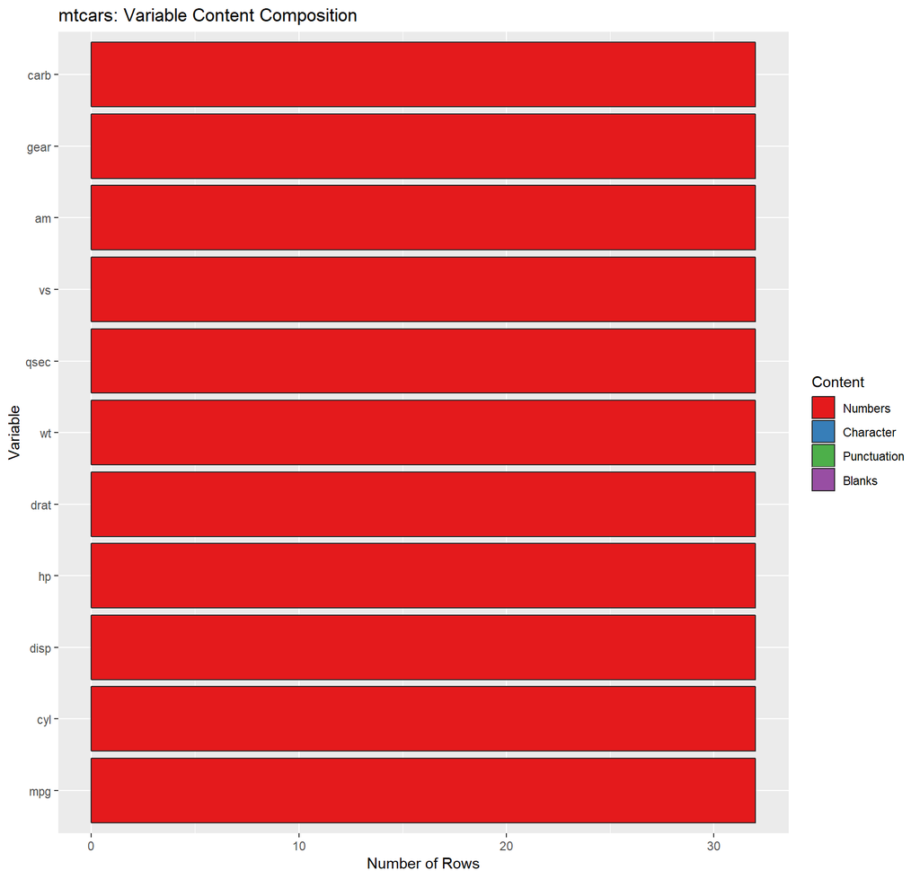

# Continuous Variables

## mpg

Summary Statistics for mpg

| Min | Mean | Median | Max | Standard Deviation |
| --- | --- | --- | --- | --- |
| 10.4 | 20.09 | 19.2 | 33.9 | 6.03 |

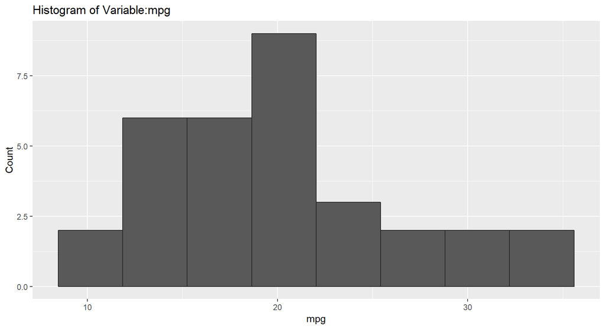

## cyl

Summary Statistics for cyl

| Min | Mean | Median | Max | Standard Deviation |
| --- | --- | --- | --- | --- |
| 4 | 6.19 | 6 | 8 | 1.79 |

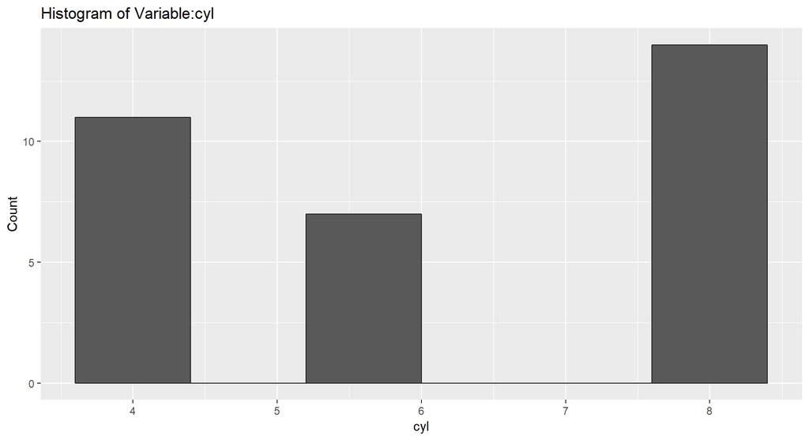

## disp

Summary Statistics for disp

| Min | Mean | Median | Max | Standard Deviation |
| --- | --- | --- | --- | --- |
| 71.1 | 230.72 | 196.3 | 472 | 123.94 |

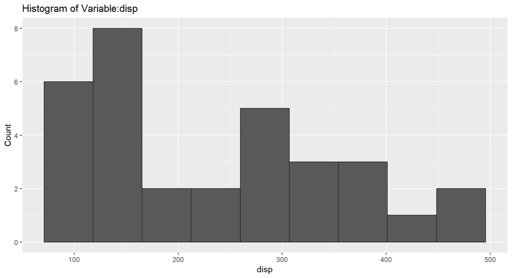

## hp

Summary Statistics for hp

| Min | Mean | Median | Max | Standard Deviation |
| --- | --- | --- | --- | --- |
| 52 | 146.69 | 123 | 335 | 68.56 |

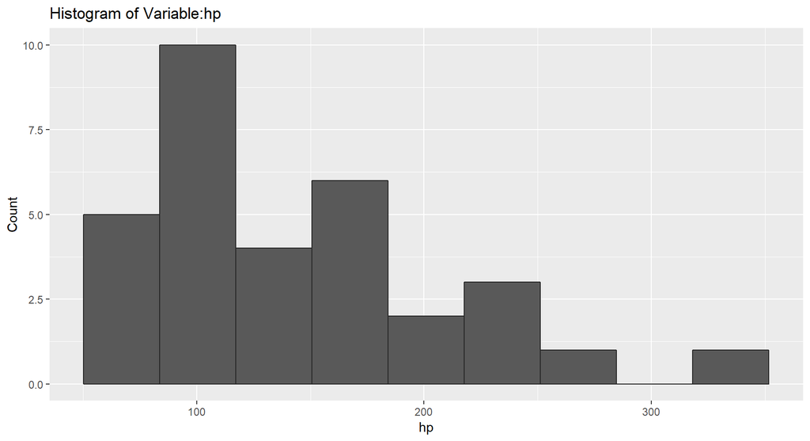

## drat

Summary Statistics for drat

| Min | Mean | Median | Max | Standard Deviation |
| --- | --- | --- | --- | --- |
| 2.76 | 3.6 | 3.7 | 4.93 | 0.53 |

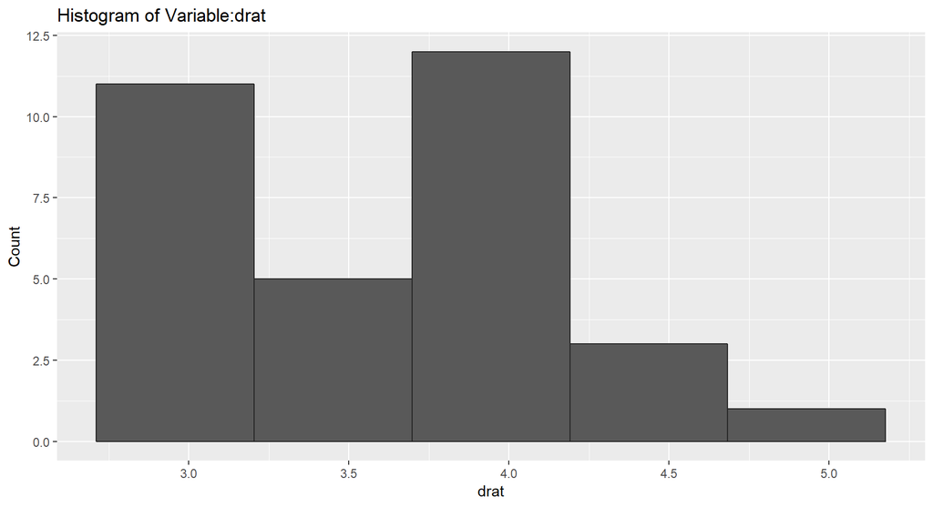

## wt

Summary Statistics for wt

| Min | Mean | Median | Max | Standard Deviation |
| --- | --- | --- | --- | --- |
| 1.51 | 3.22 | 3.33 | 5.42 | 0.98 |

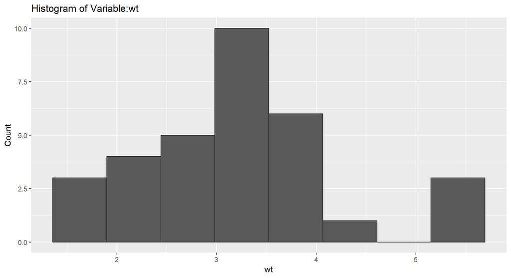

## qsec

Summary Statistics for qsec

| Min | Mean | Median | Max | Standard Deviation |
| --- | --- | --- | --- | --- |
| 14.5 | 17.85 | 17.71 | 22.9 | 1.79 |

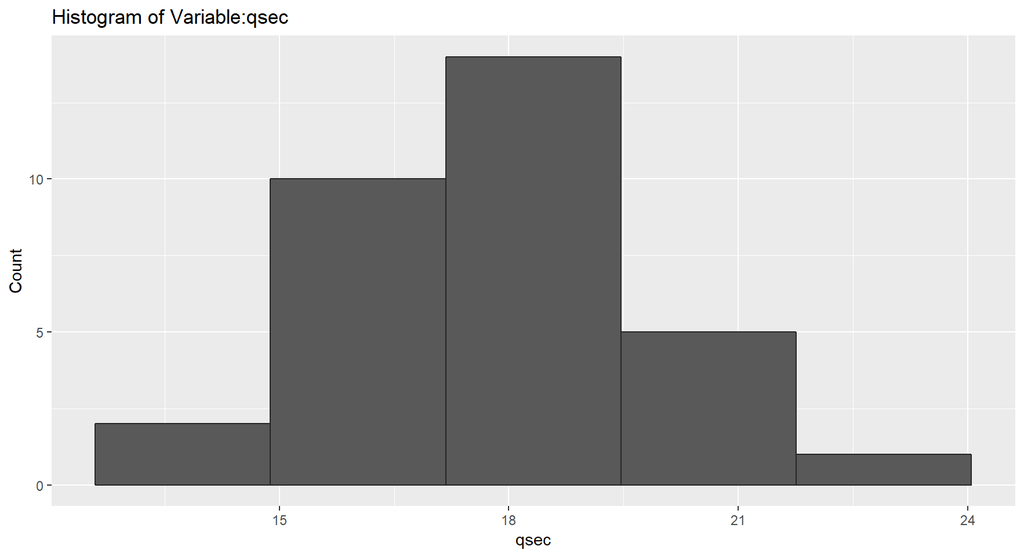

## vs

Summary Statistics for vs

| Min | Mean | Median | Max | Standard Deviation |
| --- | --- | --- | --- | --- |
| 0 | 0.44 | 0 | 1 | 0.5 |

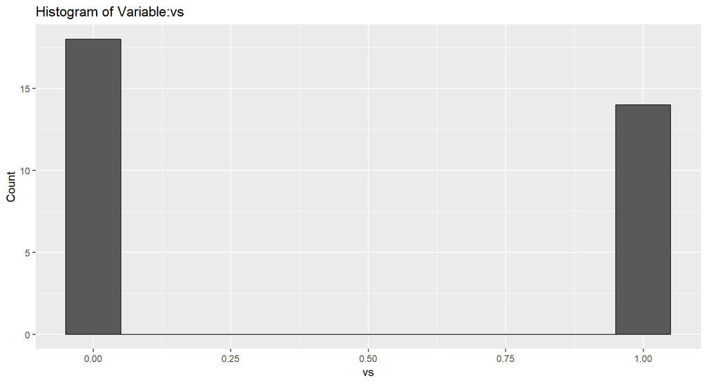

## am

Summary Statistics for am

| Min | Mean | Median | Max | Standard Deviation |
| --- | --- | --- | --- | --- |
| 0 | 0.41 | 0 | 1 | 0.5 |

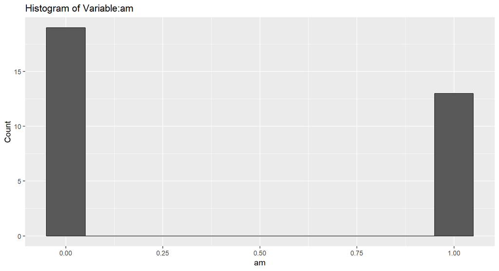

## gear

Summary Statistics for gear

| Min | Mean | Median | Max | Standard Deviation |
| --- | --- | --- | --- | --- |
| 3 | 3.69 | 4 | 5 | 0.74 |

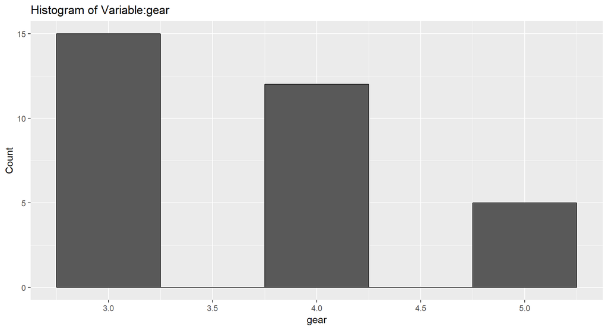

## carb

Summary Statistics for carb

| Min | Mean | Median | Max | Standard Deviation |
| --- | --- | --- | --- | --- |
| 1 | 2.81 | 2 | 8 | 1.62 |

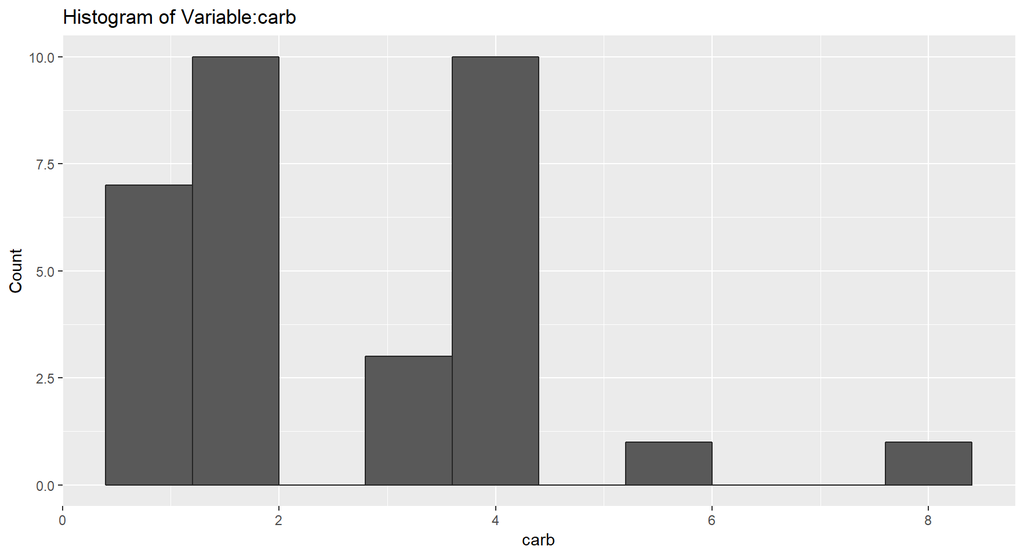

```r
if (length(names(dplyr::select_if(params$dat, funs(is.character(.) | is.factor(.))))) == 0) {
  cat_log <- FALSE
}
```

Process Time: 0.5 minutes  
R version 3.5.1 (2018-07-02)  
Report by the Centre for Global Health Research